# act_report

## Report: act_report

Following the data wrangling of the data on tweets made on the WeRateDogs Twitter page, the following insights have been observed:

#### 1st insight

In terms of the Twitter account WeRateDogs activity portrayed by the data at hand, between 2015 - 2017, 2016 had almost half of the total activity at 48%, with the second most active year being 2015. Our data shows that 2017 had by far the lowest activity calculated at 18%.

In terms of the highest rates given to pictures posted by WeRateDogs, we can observe a constant positive trend. The mean score given in 2015 was 9.26 in 2016 10.73 and in 2017 12.47.

#### 3rd insight

The neural network predictions tend to agree between each other, based on the data at hand. WIth a 60% rate neural network predicted that in the picture there is a dog. However, the disagreement between predictions occured only at 16% i.e. when one prediction suggested that there is not a dog and the others that there is one.

Also, the neural network agreed upon whether there is not a dog in the picture. With a score of 15% all three predictions pointed out that there is not a dog in the picture. The percentage of disagreement between the predictions is similarly low. Similarly to the above, the disagreement only occured at almost 8% rate i.e. when only one prediction suggested that there is a dog and the others that there not one there.

#### Visualization

In order to better convey the insights regarding the relation between ratings and favored pictures, a bar char has been produced. Please find below the ratings of pictures based on four groups of favored pictures: Low, Medium, Moderately High and High.

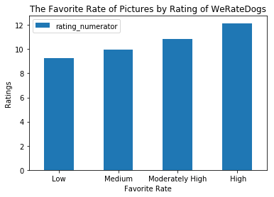